# Ejercicios_Tema_5

Jose Manuel Valdeolmillos

16 de agosto de 2016

## Ejercicio 1

Se desea probar la fuerza de un compuesto termoplástico (“strength”) dependiendo de la potencia de un láser (“laser”, 40, 50 o 60W) y la velocidad de una cinta (“tape”, slow=6.42 m/s, medium=13m/s y fast=27m/s). Realice el análisis que corresponda e interprete los resultados.

```r
library(faraway)
data(composite, package="faraway")
head(composite)
```

```
##   strength laser   tape
## 1    25.66   40W   slow
## 2    29.15   50W   slow
## 3    35.73   60W   slow
## 4    28.00   40W medium
## 5    35.09   50W medium
## 6    39.56   60W medium
```

```r
str(composite)
```

```
## 'data.frame':    9 obs. of  3 variables:
##  $ strength: num  25.7 29.1 35.7 28 35.1 ...
##  $ laser   : Factor w/ 3 levels "40W","50W","60W": 1 2 3 1 2 3 1 2 3
##  $ tape    : Factor w/ 3 levels "slow","medium",..: 1 1 1 2 2 2 3 3 3
```

```r
xtabs(strength ~ tape + laser, data = composite)
```

```
##         laser
## tape       40W   50W   60W
##   slow   25.66 29.15 35.73
##   medium 28.00 35.09 39.56
##   fast   20.65 29.79 35.66
```

### Graficamos

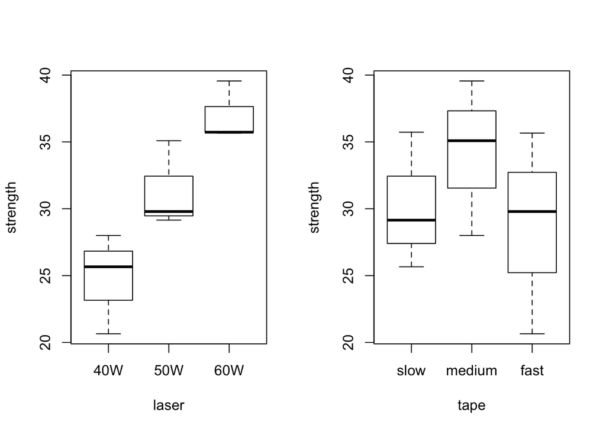

```r
par(mfrow = c(1,2))
plot(strength ~ laser, data = composite)
plot(strength ~ tape, data = composite)
```

Se aprecia que existe heterogeneidad, no hay outliers y también se aprecia diferencia de medias, sobre todo en la potencia de láser.

### Evaluamos la interacción de los factores

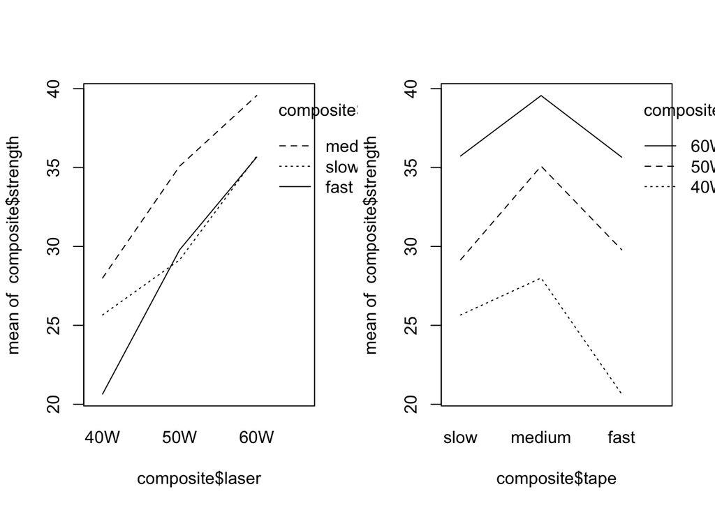

```r
par(mfrow = c(1,2))
interaction.plot(composite$laser, composite$tape, composite$strength)
interaction.plot(composite$tape, composite$laser, composite$strength)
```

En cuanto a Velocidad de la cinta se aprecia que casi llegan a ser paralelas y en la potencia de láser se aprecia, pero no tan claramente. Por lo que en un principio parece que haya interacción entre ambos factores.

```r
library(asbio)
with(composite, tukey.add.test(strength, tape, laser))
```

```
##
## Tukey's one df test for additivity
## F = 0.4500562   Denom df = 3    p-value = 0.5503385
```

p-valor > 0.05 no existe efecto de interacción entre laser y velocidad de la cinta.

### Trabajamos sin interacción. Modelo y ANOVA

```r
g <- lm(strength ~ laser + tape, composite)
anova(g)
```

```
## Analysis of Variance Table
##
## Response: strength
##           Df  Sum Sq Mean Sq F value   Pr(>F)
## laser      2 224.184 112.092 42.6893 0.002003 **
## tape       2  48.919  24.459  9.3151 0.031242 *
## Residuals  4  10.503   2.626
## ---
## Signif. codes:  0 '***' 0.001 '**' 0.01 '*' 0.05 '.' 0.1 ' ' 1
```

```r
summary(g)
```

```
##
## Call:
## lm(formula = strength ~ laser + tape, data = composite)
##
## Residuals:
##        1        2        3        4        5        6        7        8
##  1.74222 -1.34111 -0.40111  0.04556  0.56222 -0.60778 -1.78778  0.77889
##        9
##  1.00889
##
## Coefficients:
##             Estimate Std. Error t value Pr(>|t|)
## (Intercept)   23.918      1.208  19.803 3.84e-05 ***
## laser50W       6.573      1.323   4.968 0.007661 **
## laser60W      12.213      1.323   9.231 0.000765 ***
## tapemedium     4.037      1.323   3.051 0.037991 *
## tapefast      -1.480      1.323  -1.119 0.325944
## ---
## Signif. codes:  0 '***' 0.001 '**' 0.01 '*' 0.05 '.' 0.1 ' ' 1
##
## Residual standard error: 1.62 on 4 degrees of freedom
## Multiple R-squared:  0.963,  Adjusted R-squared:  0.9259
## F-statistic:    26 on 4 and 4 DF,  p-value: 0.004013
```

El modelo es significativo (0.004) y el ajuste es muy bueno (0.963). Se aprecia que el factor que más significación aporta es la potencia del láser.

También se aprecia, aunque con menos fuerza, en el efecto de la velocidad de la cinta.

### Obtenemos las medias para cada interacción

```r
attach(composite)
tapply(strength, laser, mean)
```

```
##      40W      50W      60W
## 24.77000 31.34333 36.98333
```

```r
tapply(strength, tape, mean)
```

```
##     slow   medium     fast
## 30.18000 34.21667 28.70000
```

```r
# agrupadas
tapply(strength, list(tape, laser),mean)
```

```
##          40W   50W   60W
## slow   25.66 29.15 35.73
## medium 28.00 35.09 39.56
## fast   20.65 29.79 35.66
```

### Comparaciones múltiples de medias post hoc

```r
(DifL <- TukeyHSD(aov(g)))
```

```
##   Tukey multiple comparisons of means
##     95% family-wise confidence level
##
## Fit: aov(formula = g)
##
## $laser
##              diff       lwr      upr     p adj
## 50W-40W  6.573333 1.8579359 11.28873 0.0166886
## 60W-40W 12.213333 7.4979359 16.92873 0.0017004
## 60W-50W  5.640000 0.9246026 10.35540 0.0281098
##
## $tape
##                  diff         lwr        upr     p adj
## medium-slow  4.036667  -0.6787308  8.7520641 0.0795266
## fast-slow   -1.480000  -6.1953974  3.2353974 0.5536542
## fast-medium -5.516667 -10.2320641 -0.8012692 0.0302456
```

Hay diferencias significativas entre la potencia de láser

Hay diferencias signiticativas entre velocidad de la cinta fast-medium.

### Diagnóstico del modelo

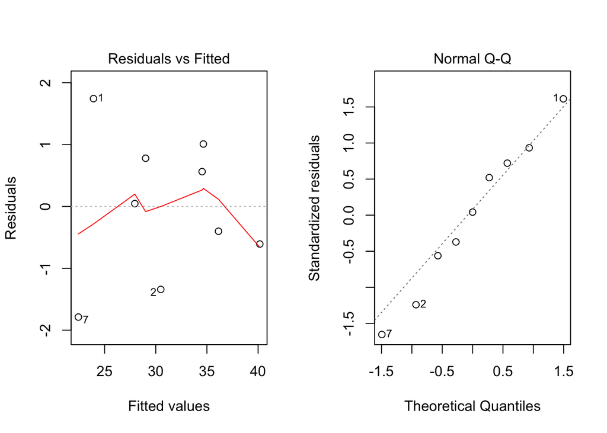

```r
par(mfrow=c(1,2))
plot(g, which = 1:2)
```

Los valores se ajustan entre -2 y 2, no parece que haya heterogeneidad de varianza. Los valores residuales se ajustan más o menos a la normalidad (excepto los puntos 2 y 7).

## Ejercicio 2

Se desea comparar el rendimiento (“yield”, gramos/16ft) de 8 variedades de avena (“variety”, 1-8). Debido a que el área donde están cultivadas es heterogénea las unidades experimentales se agruparon en 5 bloques (“block”, I-V). Realice el análisis que corresponda e interprete los resultados.

```r
library(faraway)
data(oatvar,package="faraway")
head(oatvar)
```

```
##   yield block variety
## 1   296     I       1
## 2   357    II       1
## 3   340   III       1
## 4   331    IV       1
## 5   348     V       1
## 6   402     I       2
```

```r
str(oatvar)
```

```
## 'data.frame':    40 obs. of  3 variables:
##  $ yield  : num  296 357 340 331 348 402 390 431 340 320 ...
##  $ block  : Factor w/ 5 levels "I","II","III",..: 1 2 3 4 5 1 2 3 4 5 ...
##  $ variety: Factor w/ 8 levels "1","2","3","4",..: 1 1 1 1 1 2 2 2 2 2 ...
```

```r
# Mostramos los datos tabulados...
xtabs(yield~ block+variety,data=oatvar)
```

```
##      variety
## block   1   2   3   4   5   6   7   8
##   I   296 402 437 303 469 345 324 488
##   II  357 390 334 319 405 342 339 374
##   III 340 431 426 310 442 358 357 401
##   IV  331 340 320 260 487 300 352 338
##   V   348 320 296 242 394 308 220 320
```

### Graficamos

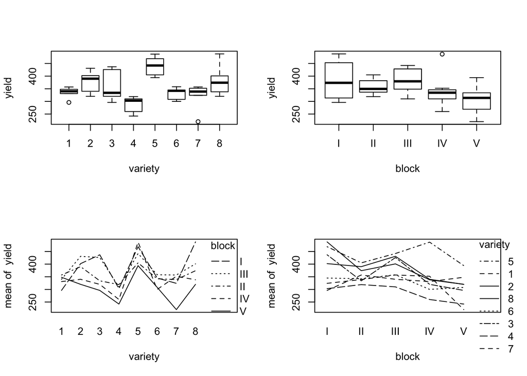

```r
par(mfrow = c(2,2))
plot(yield ~ variety, data = oatvar)
plot(yield ~ block, data = oatvar)
with(oatvar, interaction.plot(variety, block, yield))
with(oatvar, interaction.plot(block, variety, yield))
```

Se detectan outliers.

Existe más heterogeneidad en las variedades que en los bloques.

### Buscamos efectos de bloque y tratamiento.

```r
# No debería existir interacción entre bloque y tratamiento. Pero vamos a realizar la prueba para salir de dudas.

library(asbio)
with(oatvar, tukey.add.test(yield, variety, block))
```

```
##
## Tukey's one df test for additivity
## F = 0.1544249   Denom df = 27    p-value = 0.6974277
```

p-valor > 0.05 no existe efecto de interacción entre variedad y bloque. Se continúa con el análisis

### Modelo y ANOVA

```r
# No debería existir interacción entre bloque y tratamiento. Pero vamos a realizar la prueba para salir de dudas.

g <- lm(yield ~ variety+block,oatvar)
anova(g)
```

```
## Analysis of Variance Table
##
## Response: yield
##           Df Sum Sq Mean Sq F value    Pr(>F)
## variety    7  77524 11074.8  8.2839 1.804e-05 ***
## block      4  33396  8348.9  6.2449  0.001008 **
## Residuals 28  37433  1336.9
## ---
## Signif. codes:  0 '***' 0.001 '**' 0.01 '*' 0.05 '.' 0.1 ' ' 1
```

```r
summary(g)
```

```
##
## Call:
## lm(formula = yield ~ variety + block, data = oatvar)
##
## Residuals:
##     Min      1Q  Median      3Q     Max
## -67.275 -19.675  -4.638  17.725  74.925
##
## Coefficients:
##             Estimate Std. Error t value Pr(>|t|)
## (Intercept)  363.275     20.027  18.139  < 2e-16 ***
## variety2      42.200     23.125   1.825 0.078707 .
## variety3      28.200     23.125   1.219 0.232841
## variety4     -47.600     23.125  -2.058 0.048968 *
## variety5     105.000     23.125   4.541 9.73e-05 ***
## variety6      -3.800     23.125  -0.164 0.870656
## variety7     -16.000     23.125  -0.692 0.494701
## variety8      49.800     23.125   2.154 0.040035 *
## blockII      -25.500     18.282  -1.395 0.174036
## blockIII       0.125     18.282   0.007 0.994593
## blockIV      -42.000     18.282  -2.297 0.029282 *
## blockV       -77.000     18.282  -4.212 0.000238 ***
## ---
## Signif. codes:  0 '***' 0.001 '**' 0.01 '*' 0.05 '.' 0.1 ' ' 1
##
## Residual standard error: 36.56 on 28 degrees of freedom
## Multiple R-squared:  0.7477, Adjusted R-squared:  0.6485
## F-statistic: 7.542 on 11 and 28 DF,  p-value: 7.723e-06
```

Se observan fuertes efectos significativos entre las variedades y menor aunque también bastante significativo entre los bloques.

El modelo es significativo (< 0.001) y el ajuste es bueno (0.75).

### Detectar diferencias significativas entre las variedades

```r
# No debería existir interacción entre bloque y tratamiento. Pero vamos a realizar la prueba para salir de dudas.

(difV <- TukeyHSD(aov(g), "variety"))
```

```
##   Tukey multiple comparisons of means
##     95% family-wise confidence level
##
## Fit: aov(formula = g)
##
## $variety
##       diff        lwr         upr     p adj
## 2-1   42.2  -33.42354 117.8235403 0.6095159
## 3-1   28.2  -47.42354 103.8235403 0.9192042
## 4-1  -47.6 -123.22354  28.0235403 0.4638341
## 5-1  105.0   29.37646 180.6235403 0.0021695
## 6-1   -3.8  -79.42354  71.8235403 0.9999998
## 7-1  -16.0  -91.62354  59.6235403 0.9965700
## 8-1   49.8  -25.82354 125.4235403 0.4078261
## 3-2  -14.0  -89.62354  61.6235403 0.9985165
## 4-2  -89.8 -165.42354 -14.1764597 0.0116440
## 5-2   62.8  -12.82354 138.4235403 0.1594614
## 6-2  -46.0 -121.62354  29.6235403 0.5061924
## 7-2  -58.2 -133.82354  17.4235403 0.2295334
## 8-2    7.6  -68.02354  83.2235403 0.9999741
## 4-3  -75.8 -151.42354  -0.1764597 0.0491482
## 5-3   76.8    1.17646 152.4235403 0.0445643
## 6-3  -32.0 -107.62354  43.6235403 0.8569155
## 7-3  -44.2 -119.82354  31.4235403 0.5549007
## 8-3   21.6  -54.02354  97.2235403 0.9798036
## 5-4  152.6   76.97646 228.2235403 0.0000094
## 6-4   43.8  -31.82354 119.4235403 0.5658118
## 7-4   31.6  -44.02354 107.2235403 0.8644352
## 8-4   97.4   21.77646 173.0235403 0.0050799
## 6-5 -108.8 -184.42354 -33.1764597 0.0014099
## 7-5 -121.0 -196.62354 -45.3764597 0.0003484
## 8-5  -55.2 -130.82354  20.4235403 0.2858981
## 7-6  -12.2  -87.82354  63.4235403 0.9993886
## 8-6   53.6  -22.02354 129.2235403 0.3194030
## 8-7   65.8   -9.82354 141.4235403 0.1237199
```

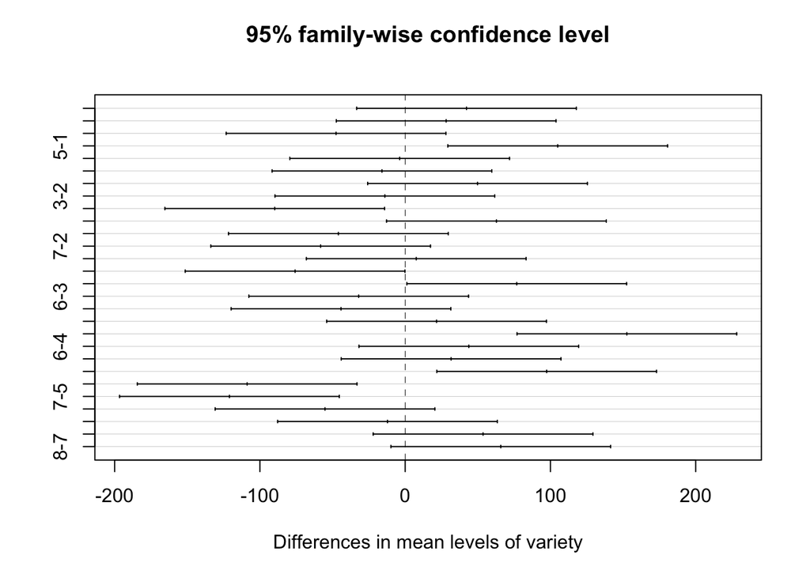

```r
plot(difV)
```

```r
(difB <- TukeyHSD(aov(g), "block"))
```

```
##   Tukey multiple comparisons of means
##     95% family-wise confidence level
##
## Fit: aov(formula = g)
##
## $block
##           diff        lwr        upr     p adj
## II-I   -25.500  -78.76401  27.764015 0.6358922
## III-I    0.125  -53.13901  53.389015 1.0000000
## IV-I   -42.000  -95.26401  11.264015 0.1756283
## V-I    -77.000 -130.26401 -23.735985 0.0020481
## III-II  25.625  -27.63901  78.889015 0.6316918
## IV-II  -16.500  -69.76401  36.764015 0.8935016
## V-II   -51.500 -104.76401   1.764015 0.0617995
## IV-III -42.125  -95.38901  11.139015 0.1734402
## V-III  -77.125 -130.38901 -23.860985 0.0020117
## V-IV   -35.000  -88.26401  18.264015 0.3333216
```

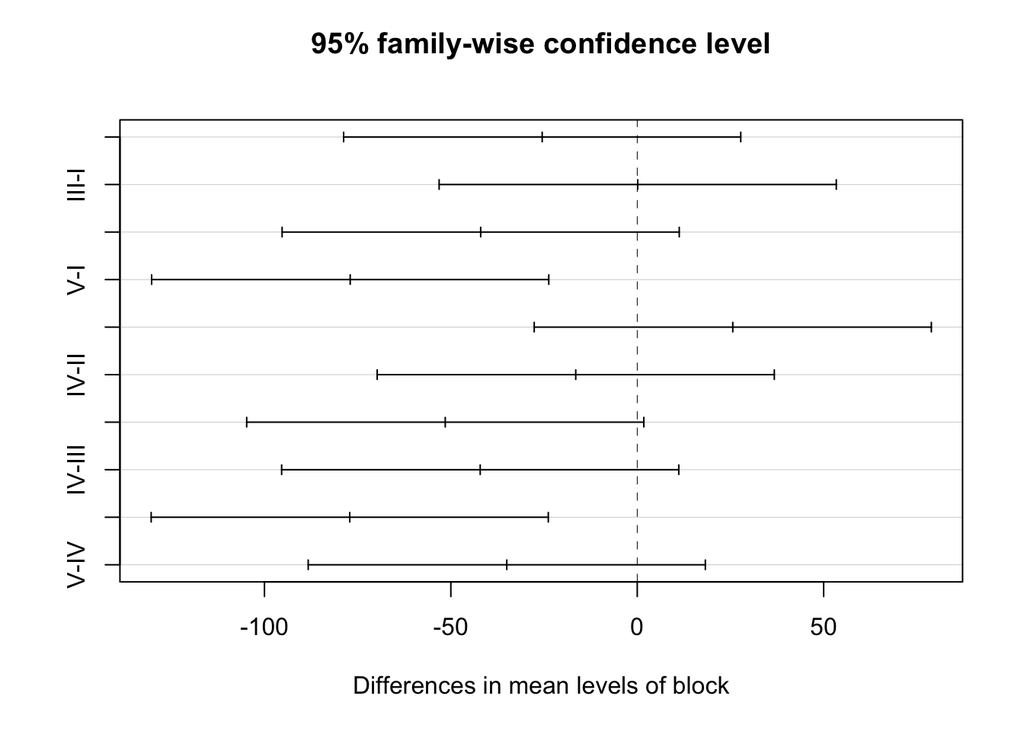

```r
plot(difB)
```

*A nivel de variedad sí existen diferencias. Las mayores las encontramos entre: La variedad 5 con 1,3,4,6 y 7. La variedad 4 con 2,3 y 8.*

*A nivel del Bloque, encontramos diferencias significativas entre los bloques V-III y V-I.*

### Diagnóstico

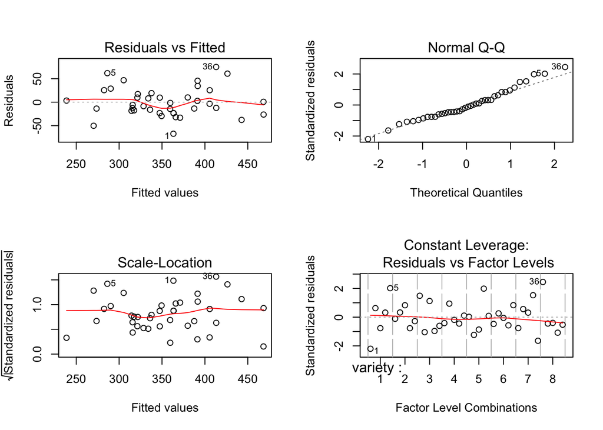

```r
par(mfrow=c(2,2))
plot(g)
```

Los valores se mueven en torno al -50 y 50, a excepción de 3 outliers detectados al inicio. Son valores con cierta homogeneidad.

La cola superior se apartan algo de la normalidad (por los valores atípicos) pero en general se ajusta.

## Ejercicio 3

Se desea comparar el desgaste de 4 tipos de materiales (“wear”, loss of weight in 0.1mm over testing period). Se cuenta con una máquina de ensayo de desgaste que registra la catidad de desgaste de cada material. Solo se pueden procesar 4 muestras al mismo tiempo y la posición de estas muestras puede ser importante. Se diseña el experimento según un cuadrado latino con un factor tratamiento que es el tipo de material (“material”, A-D), y dos factores de bloque que corresponden a la ejecución (“run”, 1-4) y a la posición (“position”, 1-4). Realice el análisis que corresponda e interprete los resultados.

```r
library(faraway)
data(abrasion,package="faraway")
head(abrasion,package="faraway")
```

```
##   run position material wear
## 1   1        1        C  235
## 2   1        2        D  236
## 3   1        3        B  218
## 4   1        4        A  268
## 5   2        1        A  251
## 6   2        2        B  241
```

```r
str(abrasion,package="faraway")
```

```
## 'data.frame':    16 obs. of  4 variables:
##  $ run     : Factor w/ 4 levels "1","2","3","4": 1 1 1 1 2 2 2 2 3 3 ...
##  $ position: Factor w/ 4 levels "1","2","3","4": 1 2 3 4 1 2 3 4 1 2 ...
##  $ material: Factor w/ 4 levels "A","B","C","D": 3 4 2 1 1 2 4 3 4 3 ...
##  $ wear    : int  235 236 218 268 251 241 227 229 234 273 ...
```

```r
#comprobamos la estructura de cuadrado latino
xtabs(wear~run+position+material,data=abrasion)
```

```
## , , material = A
##
##    position
## run   1   2   3   4
##   1   0   0   0 268
##   2 251   0   0   0
##   3   0   0 274   0
##   4   0 270   0   0
##
## , , material = B
##
##    position
## run   1   2   3   4
##   1   0   0 218   0
##   2   0 241   0   0
##   3   0   0   0 226
##   4 195   0   0   0
##
## , , material = C
##
##    position
## run   1   2   3   4
##   1 235   0   0   0
##   2   0   0   0 229
##   3   0 273   0   0
##   4   0   0 230   0
##
## , , material = D
##
##    position
## run   1   2   3   4
##   1   0 236   0   0
##   2   0   0 227   0
##   3 234   0   0   0
##   4   0   0   0 225
```

```r
matrix(abrasion$material,4,4)
```

```
##      [,1] [,2] [,3] [,4]
## [1,] "C"  "A"  "D"  "B"
## [2,] "D"  "B"  "C"  "A"
## [3,] "B"  "D"  "A"  "C"
## [4,] "A"  "C"  "B"  "D"
```

### Graficamos…

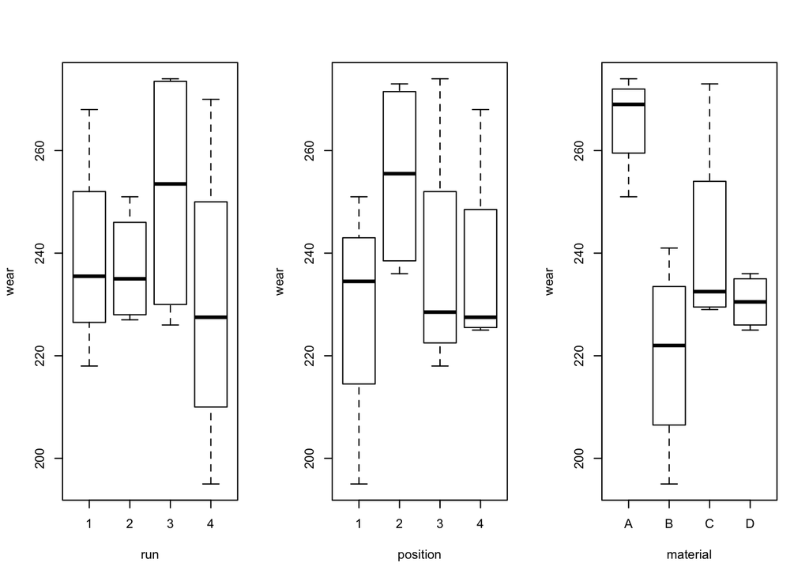

```r
par(mfrow=c(1,3))
plot(wear ~ run , abrasion)
plot(wear ~ position , abrasion)
plot(wear ~ material, abrasion)
```

Donde más diferencia parece haber es en los materiales, aunque por narma general parece que en los 3 casos siempr hay una de las medias de cada factor que difiere del resto y las demás más o menos son homogéneas.

No se detectan oultiers.

### Modelo y ANOVA

En principio no asumimos para este modelo que haya ningún tipo de interacción.

```r
g <- lm(wear ~ run+position+material, data = abrasion)
anova(g)
```

```
## Analysis of Variance Table
##
## Response: wear
##           Df Sum Sq Mean Sq F value    Pr(>F)
## run        3  986.5  328.83  5.3687 0.0390130 *
## position   3 1468.5  489.50  7.9918 0.0161685 *
## material   3 4621.5 1540.50 25.1510 0.0008498 ***
## Residuals  6  367.5   61.25
## ---
## Signif. codes:  0 '***' 0.001 '**' 0.01 '*' 0.05 '.' 0.1 ' ' 1
```

```r
summary(g)
```

```
##
## Call:
## lm(formula = wear ~ run + position + material, data = abrasion)
##
## Residuals:
##    Min     1Q Median     3Q    Max
## -9.750 -2.250  0.250  3.688  8.000
##
## Coefficients:
##             Estimate Std. Error t value Pr(>|t|)
## (Intercept)  254.750      6.187  41.174 1.37e-08 ***
## run2          -2.250      5.534  -0.407 0.698423
## run3          12.500      5.534   2.259 0.064657 .
## run4          -9.250      5.534  -1.671 0.145658
## position2     26.250      5.534   4.743 0.003180 **
## position3      8.500      5.534   1.536 0.175454
## position4      8.250      5.534   1.491 0.186608
## materialB    -45.750      5.534  -8.267 0.000169 ***
## materialC    -24.000      5.534  -4.337 0.004892 **
## materialD    -35.250      5.534  -6.370 0.000703 ***
## ---
## Signif. codes:  0 '***' 0.001 '**' 0.01 '*' 0.05 '.' 0.1 ' ' 1
##
## Residual standard error: 7.826 on 6 degrees of freedom
## Multiple R-squared:  0.9506, Adjusted R-squared:  0.8766
## F-statistic: 12.84 on 9 and 6 DF,  p-value: 0.002828
```

Para los tres, existen efectos significativos, aunque el más fuerte es el que aparece en el tipo de material (que aparece para todos), pues en el resto sólo difiere uno de ellos.

El modelo es significativo (< 0.003) y el ajuste es muy bueno (0.87).

### Comparaciones múltiples de medias Post Hoc solo para material.

```r
TukeyHSD(aov(g))$material
```

```
##       diff        lwr        upr        p adj
## B-A -45.75 -64.907062 -26.592938 0.0007030032
## C-A -24.00 -43.157062  -4.842938 0.0190355514
## D-A -35.25 -54.407062 -16.092938 0.0028662067
## C-B  21.75   2.592938  40.907062 0.0294773816
## D-B  10.50  -8.657062  29.657062 0.3206305794
## D-C -11.25 -30.407062   7.907062 0.2742765205
```

```r
# graficamos...
par(mfrow=c(1,1))
(difM <- TukeyHSD(aov(g), "material"))
```

```
##   Tukey multiple comparisons of means
##     95% family-wise confidence level
##
## Fit: aov(formula = g)
##
## $material
##       diff        lwr        upr     p adj
## B-A -45.75 -64.907062 -26.592938 0.0007030
## C-A -24.00 -43.157062  -4.842938 0.0190356
## D-A -35.25 -54.407062 -16.092938 0.0028662
## C-B  21.75   2.592938  40.907062 0.0294774
## D-B  10.50  -8.657062  29.657062 0.3206306
## D-C -11.25 -30.407062   7.907062 0.2742765
```

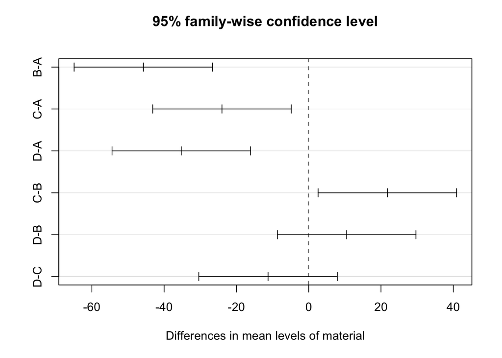

```r
plot(difM)
```

Se aprecia la diferencia más significativa entre el material A y el resto de los materiales principalmente. También se aprecia diferencia, aunque no tan significativa entre C-B.

### Estimaciones de los efectos

```r
summary(g)
```

```
##
## Call:
## lm(formula = wear ~ run + position + material, data = abrasion)
##
## Residuals:
##    Min     1Q Median     3Q    Max
## -9.750 -2.250  0.250  3.688  8.000
##
## Coefficients:
##             Estimate Std. Error t value Pr(>|t|)
## (Intercept)  254.750      6.187  41.174 1.37e-08 ***
## run2          -2.250      5.534  -0.407 0.698423
## run3          12.500      5.534   2.259 0.064657 .
## run4          -9.250      5.534  -1.671 0.145658
## position2     26.250      5.534   4.743 0.003180 **
## position3      8.500      5.534   1.536 0.175454
## position4      8.250      5.534   1.491 0.186608
## materialB    -45.750      5.534  -8.267 0.000169 ***
## materialC    -24.000      5.534  -4.337 0.004892 **
## materialD    -35.250      5.534  -6.370 0.000703 ***
## ---
## Signif. codes:  0 '***' 0.001 '**' 0.01 '*' 0.05 '.' 0.1 ' ' 1
##
## Residual standard error: 7.826 on 6 degrees of freedom
## Multiple R-squared:  0.9506, Adjusted R-squared:  0.8766
## F-statistic: 12.84 on 9 and 6 DF,  p-value: 0.002828
```

*El desgaste es mayor en los materiales A y C. Siendo B y D los que menor desgaste sufrieron.*

### Diagnóstico

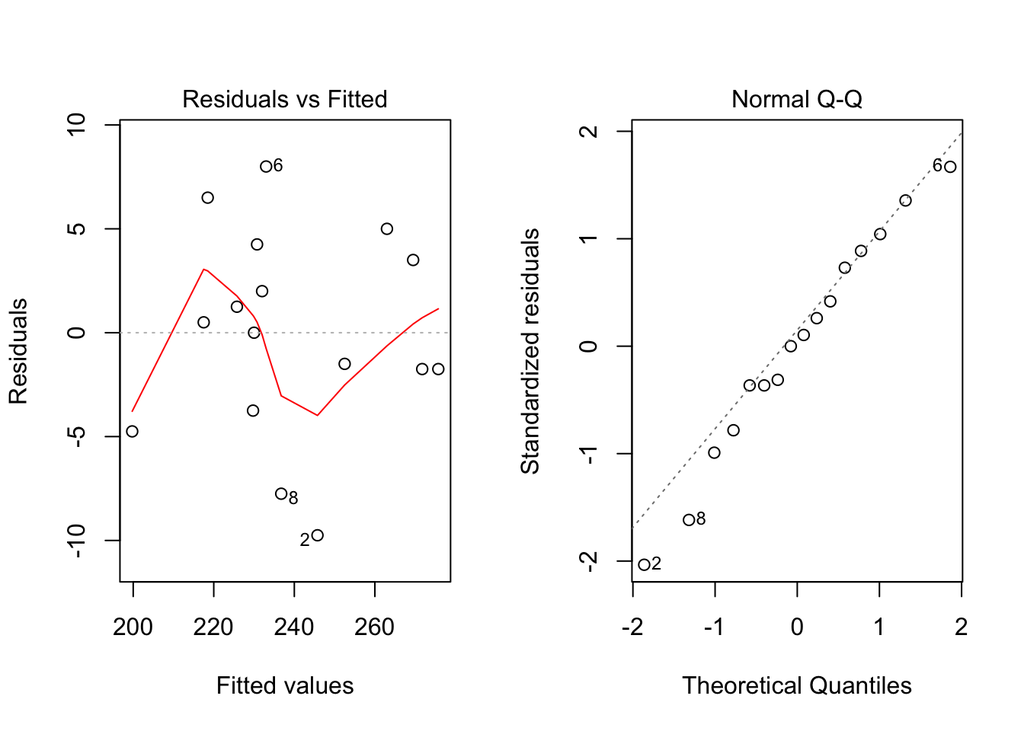

```r
par(mfrow=c(1,2))
plot(g, which = 1:2)
```

Se muestran algunos outliers y algunas diferencias respecto a la normalidad.

También se muestra algo de heterogeneidad.

## Ejercicio 4

- isolated = se mantuvo aislado
- one = 1 hembra vírgen cada día
- many = 8 hembras preñadas cada día que no se acoplarán
- low= 1 hembra vírgen cada día
- high = 8 hembras vírgenes cada día.

Realice el análisis que corresponda e interprete los resultados.

```r
library(faraway)
library(WRS2)
data(fruitfly)
head(fruitfly)
```

```
##   thorax longevity activity
## 1   0.68        37     many
## 2   0.68        49     many
## 3   0.72        46     many
## 4   0.72        63     many
## 5   0.76        39     many
## 6   0.76        46     many
```

```r
str(fruitfly)
```

```
## 'data.frame':    124 obs. of  3 variables:
##  $ thorax   : num  0.68 0.68 0.72 0.72 0.76 0.76 0.76 0.76 0.76 0.8 ...
##  $ longevity: int  37 49 46 63 39 46 56 63 65 56 ...
##  $ activity : Factor w/ 5 levels "isolated","one",..: 4 4 4 4 4 4 4 4 4 4 ...
```

Nos interesa comparar los valores thorax y longevidad para lo cual utilizaremos longevidad como variable dependiente y thorax como covariable, comparando los grupos low y high.

### Modificación de los datos (según código adjunto) y graficado…

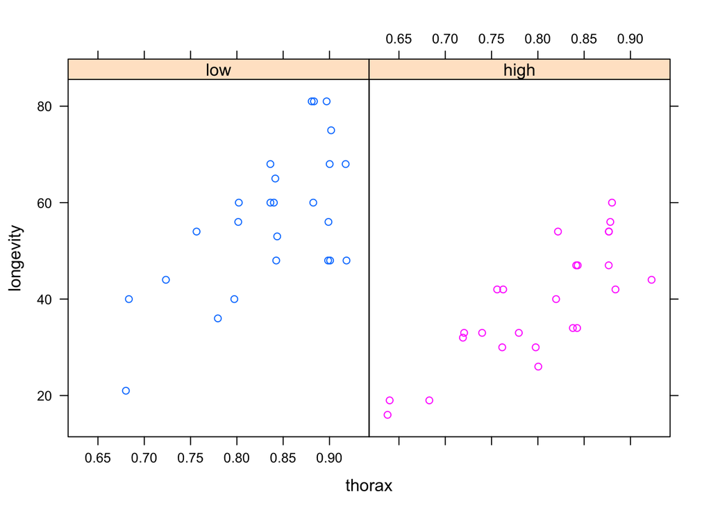

```r
df=fruitfly[fruitfly$activity %in% c("low","high"),]
df$activity<-droplevels(df$activity)
df$thorax<-jitter(df$thorax)
row.names(df)<-NULL

# Graficado mediante Lattice
library(lattice)

par(cex = .6)
xyplot(longevity ~ thorax|activity, data = df, group=activity, type = "p")
```

A simple vista se aprecia una alta longevidad en la activity “low” vs. “high” según aumenta la variable “thorax”. Estando el grueso de datos entre 30 y 60 días para “high”, mientras que para “low” se halla entre 50 y 80 días.

### ANCOVA.

```r
(fitanc <-ancova(longevity~thorax+activity, data=df))
```

```
## Call:
## ancova(formula = longevity ~ thorax + activity, data = df)
##
##                            n: low n: high trimmed mean diff     se
## thorax = 0.77947720618546      12      15           18.4861 3.6525
## thorax = 0.836165205091238     20      18           16.0000 4.2935
## thorax = 0.84352674530074      21      18           16.0641 4.2624
## thorax = 0.896929277600721     17      13           14.2424 4.6237
## thorax = 0.901790928497911     17      13           14.2424 4.6237
##                            lower CI upper CI statistic p-value
## thorax = 0.77947720618546    7.5513  29.4210    5.0613  0.0003
## thorax = 0.836165205091238   4.0094  27.9906    3.7266  0.0012
## thorax = 0.84352674530074    4.2060  27.9222    3.7688  0.0010
## thorax = 0.896929277600721   0.8927  27.5922    3.0803  0.0071
## thorax = 0.901790928497911   0.8927  27.5922    3.0803  0.0071
```

Vemos que existen diferencias en todos los cortes (p-valor < 0.05).

## Graficamos.

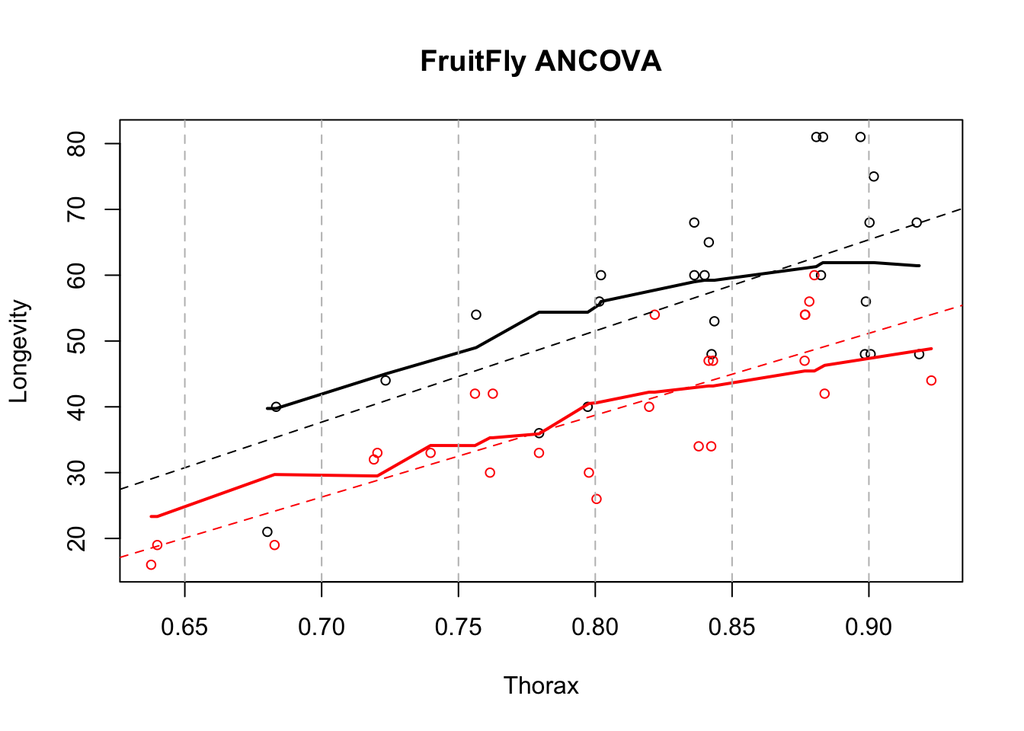

```r
plot(df$thorax, df$longevity, col=rep(1:2, each = 25), pch = 1, cex = 0.8,
    xlab = "Thorax", ylab = "Longevity", main = "FruitFly ANCOVA")
fflw <- subset(df, subset = activity == "low")
ffhg <- subset(df, subset = activity == "high")
ordlw <- order(fflw$thorax)
lines(fflw$thorax[ordlw], fitanc$fitted.values$low[ordlw], col=1, lwd=2)
# Es la regresión para low
abline(lm(fflw$longevity ~ fflw$thorax), col = 1, lty = 2)

ordhg<- order(ffhg$thorax)
lines(ffhg$thorax[ordhg], fitanc$fitted.values$high[ordhg], col=2, lwd=2)

# Es la regresión para high.
abline(lm(ffhg$longevity ~ ffhg$thorax), col = 2, lty = 2)
abline(v = c(0.65, 0.70, 0.75, 0.80, 0.85, 0.90), lty=2, col="grey")
legend(x = 20, y = 20, legend = c("low", "high"), lty = 1, col = 1:2)
```

*Color negro es para Low*

*Color rojo para high*

Se aprecian rectas de regresión paralelas donde vemos que el aumento de la covarible de Thorax hace aumentar la longevidad en la mosca.

También se aprecia que la Longevidad al aumentar la covariable Thorax es mayor en el grupo de actividad “Low”, respecto a la actividad “High”.